# Copy of NLP_Project_Full_Code-1

### Bivariate Analysis

- Correlation
- Sentiment Polarity vs Price
- Date vs Price

**Note**: The above points are listed to provide guidance on how to approach bivariate analysis. Analysis has to be done beyond the above listed points to get maximum scores.

#### Correlation

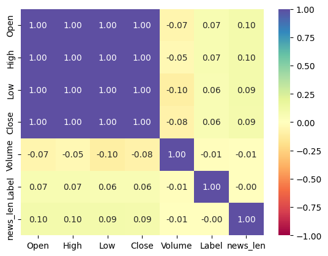

```python
# Plot the correlation matrix for numeric columns only.

sns.heatmap(
    stock.select_dtypes(include='number').corr(), annot=True, vmin=-1, vmax=1, fmt=".2f", cmap="Spectral"
);
```

- Aside from the Open, High, Low, Close variables which are tightly corelated, as already stated previously, we do not see any very strong correlation between the variables.

#### Label vs Price (Open, High, Low, Close)

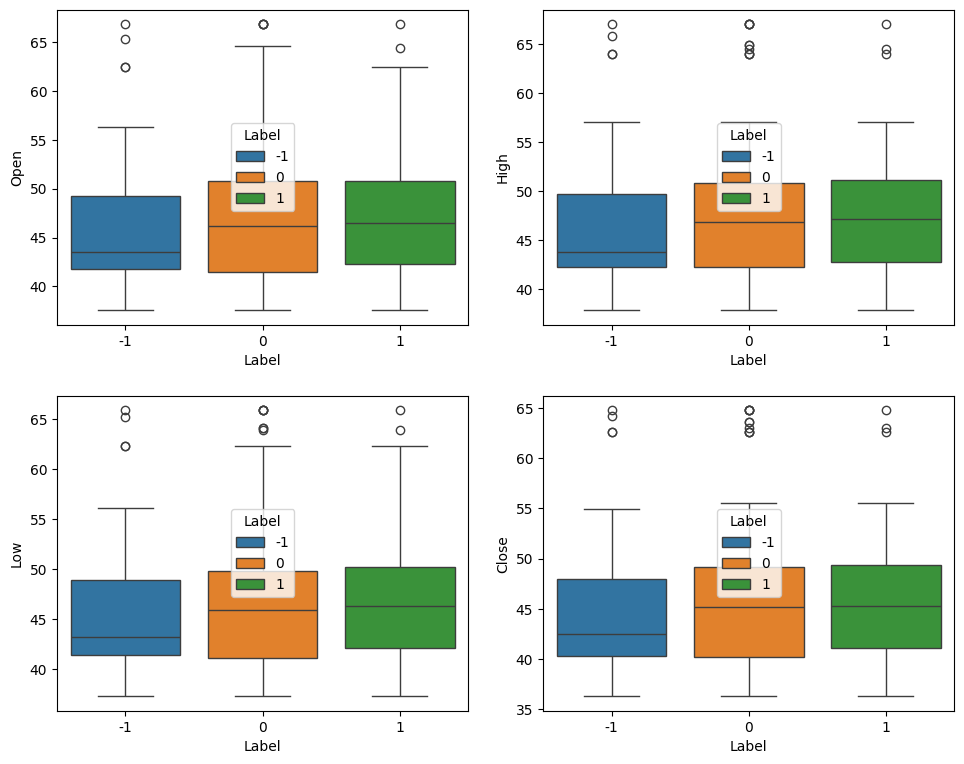

```python
plt.figure(figsize=(10, 8))

for i, variable in enumerate(['Open', 'High', 'Low', 'Close']):
    plt.subplot(2, 2, i + 1)
    sns.boxplot(data=stock, x="Label", y=variable, hue="Label", palette="tab10")
    plt.tight_layout(pad=2)

plt.show()
```

- The sentiment data patterns for the Open, High, Low, Close are very similar.
- For Negative sentiments, the values for these columns are between about 42.5 and 45; for Neutral sentiments, it is between about 45 to 47; for Positive sentiments, it is just slighter higher thean that of the Neutral sentiments for each column between about 45 and 47.5.
- There are outliers for all the columns for all the sentiments at the upper side of the data.

#### Label vs Volume

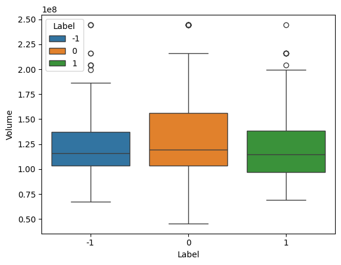

```python
sns.boxplot(
    data=stock, x="Label", y="Volume", hue="Label", palette="tab10"
);
```

- The mean and median of the Volume for Negative sentiment are about 127 and 116 million, respectively.
- The mean and median of the Volume for Neutral sentiment are about 132 and 119 million, respectively.
- The mean and median of the Volume for Positive sentiment are about 125 and 115 million, respectively.
- There are outliers on the upper side of the Volume numbers for all sentiment types.